# Lyra Health - Take Home

## Problem Statement

Lyra Health is looking to expand its products to include an online full service pharmacy, which delivers medication to their clients. One of the demographic groups that the company is interested in is the elderly population. Should Lyra Health target this group and what states should they look into?

## Import Libraries

```python
import pandas as pd
import matplotlib.pyplot as plt
import seaborn as sns
import numpy as np
```

## Importing and Cleaning Dataset

### Medicare Part D Prescriber Public Use File

(Source: https://www.cms.gov/Research-Statistics-Data-and-Systems/Statistics-Trends-and-Reports/Medicare-Provider-Charge-Data/PartD2017.html)

This dataset provides information on prescription drugs prescribed by individual physicians and other health care providers and paid for under the Medicare Part D Prescription Drug Program. It contains the overall drug utilization (number of claims, number of 30-Day fills, and number of day’s supply), total drug costs, and beneficiary counts organized at the provider level.

```python
provider = pd.read_csv('PartD_Prescriber_PUF_NPI_17.txt', sep='\t')
provider.head()
```

|  | npi | nppes_provider_last_org_name | nppes_provider_first_name | nppes_provider_mi | nppes_credentials | nppes_provider_gender | nppes_entity_code | nppes_provider_street1 | nppes_provider_street2 | nppes_provider_city | ... | beneficiary_male_count | beneficiary_race_white_count | beneficiary_race_black_count | beneficiary_race_asian_pi_count | beneficiary_race_hispanic_count | beneficiary_race_nat_ind_count | beneficiary_race_other_count | beneficiary_nondual_count | beneficiary_dual_count | beneficiary_average_risk_score |
| --- | --- | --- | --- | --- | --- | --- | --- | --- | --- | --- | --- | --- | --- | --- | --- | --- | --- | --- | --- | --- | --- |
| 0 | 1003000126 | ENKESHAFI | ARDALAN | NaN | M.D. | M | I | 900 SETON DR | NaN | CUMBERLAND | ... | 92.0 | 220.0 | 14.0 | 0.0 | 0.0 | 0.0 | 0.0 | 143.0 | 91.0 | 2.1685 |
| 1 | 1003000142 | KHALIL | RASHID | NaN | M.D. | M | I | 4126 N HOLLAND SYLVANIA RD | SUITE 220 | TOLEDO | ... | 92.0 | 195.0 | 58.0 | NaN | NaN | 0.0 | NaN | 143.0 | 133.0 | 1.8029 |
| 2 | 1003000167 | ESCOBAR | JULIO | E | DDS | M | I | 5 PINE CONE RD | NaN | DAYTON | ... | 17.0 | NaN | 0.0 | 0.0 | NaN | 0.0 | 0.0 | NaN | NaN | 1.0598 |
| 3 | 1003000175 | REYES-VASQUEZ | BELINDA | NaN | D.D.S. | F | I | 322 N AZUSA AVE STE 202 | NaN | LA PUENTE | ... | NaN | NaN | NaN | NaN | NaN | NaN | NaN | NaN | NaN | NaN |
| 4 | 1003000282 | BLAKEMORE | ROSIE | K | FNP | F | I | TENNESSEE PRISON FOR WOMEN | 3881 STEWARTS LANE | NASHVILLE | ... | NaN | NaN | NaN | 0.0 | NaN | 0.0 | 0.0 | NaN | NaN | 4.5148 |

5 rows × 84 columns

```python
non_us = provider[provider.nppes_provider_country != 'US']
print(len(non_us))
non_us[['nppes_provider_zip4', 'nppes_provider_city', 'nppes_provider_state', 'nppes_provider_country']].head()
```

```
166
```

|  | nppes_provider_zip4 | nppes_provider_city | nppes_provider_state | nppes_provider_country |
| --- | --- | --- | --- | --- |
| 3675 | NaN | WATERLOO | ZZ | CA |
| 12358 | 3.0 | SHANGHAI | ZZ | CN |
| 19753 | NaN | FPO AE | ZZ | ES |
| 22320 | NaN | APO | ZZ | DE |
| 24980 | NaN | LANCASTER | ZZ | AA |

There seems to be 166 non-US providers included in this dataset. However, for this analysis I will focus on the providers in the US.

```python
# Filtering for US providers
us_provider = provider[provider.nppes_provider_country == 'US'][['npi', 'nppes_provider_gender',
       'nppes_entity_code', 'nppes_provider_city','nppes_provider_state', 'specialty_description', 'total_claim_count',
       'total_30_day_fill_count', 'total_drug_cost', 'total_day_supply','bene_count', 'average_age_of_beneficiaries',
       'beneficiary_age_less_65_count', 'beneficiary_age_65_74_count', 'beneficiary_age_75_84_count',
       'beneficiary_age_greater_84_count', 'beneficiary_female_count', 'beneficiary_male_count', 'beneficiary_race_white_count',
       'beneficiary_race_black_count', 'beneficiary_race_asian_pi_count','beneficiary_race_hispanic_count', 'beneficiary_race_nat_ind_count',
       'beneficiary_race_other_count', 'beneficiary_nondual_count', 'beneficiary_dual_count', 'beneficiary_average_risk_score']]
del(provider)
```

### Validating the Data

```python
us_provider.drop(columns = 'npi').describe()
```

[output not shown]

8 rows × 21 columns

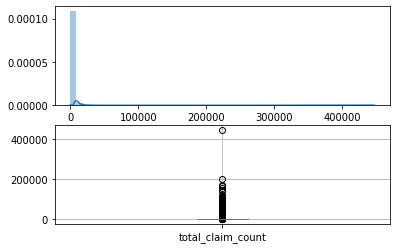

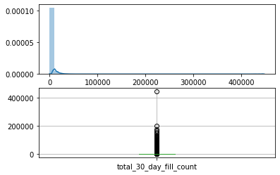

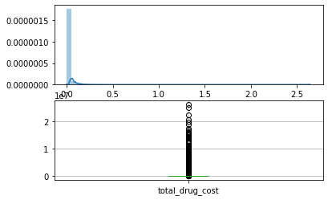

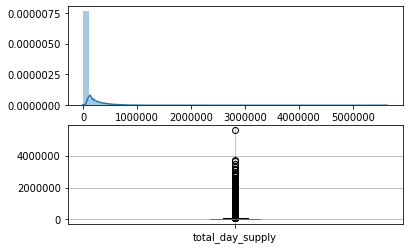

```python
def dist_graph(colname):
    f, (ax1, ax2) = plt.subplots(2, 1)
    sns.distplot(us_provider[colname], ax = ax1)
    us_provider.boxplot(colname, ax = ax2)
    plt.show()

metrics = ['total_claim_count', 'total_30_day_fill_count', 'total_drug_cost', 'total_day_supply']
for colname in metrics:
    dist_graph(colname)
```

Above is a statistical summary of the numerical variables. It summarizes the central tendency, dispersion and shape of a dataset’s distribution, excluding NaN values. As shown, there seems to be an extremely high variation for total_claim_count, total_30_day_fill_count, total_drug_cost, and total_day_supply. The distribution plots and box plots illustrates that the distribution is highly right skewed. The data is from CMS’s Chronic Conditions Data Warehouse, which contains Prescription Drug Event records submitted by Medicare Advantage Prescription Drug (MAPD) plans and by stand-alone Prescription Drug Plans (PDP). To determine the validity in the value of these outliers, I would need to research more on how the records were submitted. However, for this analysis, I will accept the values as is.

### Filling in Missing Values

```python
us_provider[us_provider.columns[us_provider.isnull().any()]].info()
```

```
<class 'pandas.core.frame.DataFrame'>
Int64Index: 1162732 entries, 0 to 1162897
Data columns (total 18 columns):
nppes_provider_gender               1162729 non-null object
bene_count                          1030928 non-null float64
average_age_of_beneficiaries        1030928 non-null float64
beneficiary_age_less_65_count       645242 non-null float64
beneficiary_age_65_74_count         540060 non-null float64
beneficiary_age_75_84_count         361481 non-null float64
beneficiary_age_greater_84_count    382501 non-null float64
beneficiary_female_count            822194 non-null float64
beneficiary_male_count              822194 non-null float64
beneficiary_race_white_count        557480 non-null float64
beneficiary_race_black_count        393899 non-null float64
beneficiary_race_asian_pi_count     510374 non-null float64
beneficiary_race_hispanic_count     404045 non-null float64
beneficiary_race_nat_ind_count      841885 non-null float64
beneficiary_race_other_count        346287 non-null float64
beneficiary_nondual_count           683551 non-null float64
beneficiary_dual_count              683551 non-null float64
beneficiary_average_risk_score      1030928 non-null float64
dtypes: float64(17), object(1)
memory usage: 168.5+ MB
```

There are 18 columns that are missing values.

3 of the providers in the dataset are organizations; therefore, it makes sense that the 'nppes_provider_gender' is missing 3 values. These values will be filled in with "Other".

Most columns have null values because count values fewer than 11 are suppressed and are indicated by a blank for privacy purposes. (See https://www.cms.gov/Research-Statistics-Data-and-Systems/Statistics-Trends-and-Reports/Medicare-Provider-Charge-Data/Downloads/Prescriber_Methods.pdf)

Not treating these values will underestimate the true value; therefore, I will fill these suppressed values with 5.

```python
# Fill in Gender
us_provider['nppes_provider_gender'] = us_provider['nppes_provider_gender'].fillna('Other')

# Fill in suppressed values
suppressed_cols = ['bene_count', 'beneficiary_age_less_65_count',
       'beneficiary_age_65_74_count', 'beneficiary_age_75_84_count',
       'beneficiary_age_greater_84_count', 'beneficiary_female_count',
       'beneficiary_male_count', 'beneficiary_race_white_count',
       'beneficiary_race_black_count', 'beneficiary_race_asian_pi_count',
       'beneficiary_race_hispanic_count', 'beneficiary_race_nat_ind_count',
       'beneficiary_race_other_count', 'beneficiary_nondual_count',
       'beneficiary_dual_count']

us_provider[suppressed_cols] = us_provider[suppressed_cols].fillna(5)
del(suppressed_cols)
```

The last 2 columns that need to be filled are average values. As illustrated by the boxplots below, the distributions tend to be skewed with outliers. I will fill the missing values with the median since it best represents the central value.

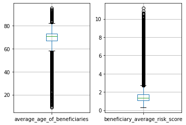

```python
f, (ax1, ax2) = plt.subplots(1, 2)
us_provider.boxplot('average_age_of_beneficiaries', ax = ax1)
us_provider.boxplot('beneficiary_average_risk_score', ax = ax2)
plt.show()
```

```python
avg_cols = ['average_age_of_beneficiaries', 'beneficiary_average_risk_score']
for col in avg_cols:
    us_provider[col] = us_provider[col].fillna(us_provider[col].median())
```

```python
#dtypes = us_provider.dtypes
#dtypes_col = dtypes.index
#dtypes_type = [i.name for i in dtypes.values]
#column_types = dict(zip(dtypes_col, dtypes_type))
#column_types = {key:'category' if value == 'object' else value for key, value in column_types.items()}

#us_provider = us_provider.astype(column_types)
us_provider.info()
```

```
<class 'pandas.core.frame.DataFrame'>
Int64Index: 1162732 entries, 0 to 1162897
Data columns (total 27 columns):
npi                                 1162732 non-null int64
nppes_provider_gender               1162732 non-null object
nppes_entity_code                   1162732 non-null object
nppes_provider_city                 1162732 non-null object
nppes_provider_state                1162732 non-null object
specialty_description               1162732 non-null object
total_claim_count                   1162732 non-null int64
total_30_day_fill_count             1162732 non-null float64
total_drug_cost                     1162732 non-null float64
total_day_supply                    1162732 non-null int64
bene_count                          1162732 non-null float64
average_age_of_beneficiaries        1162732 non-null float64
beneficiary_age_less_65_count       1162732 non-null float64
beneficiary_age_65_74_count         1162732 non-null float64
beneficiary_age_75_84_count         1162732 non-null float64
beneficiary_age_greater_84_count    1162732 non-null float64
beneficiary_female_count            1162732 non-null float64
beneficiary_male_count              1162732 non-null float64
beneficiary_race_white_count        1162732 non-null float64
beneficiary_race_black_count        1162732 non-null float64
beneficiary_race_asian_pi_count     1162732 non-null float64
beneficiary_race_hispanic_count     1162732 non-null float64
beneficiary_race_nat_ind_count      1162732 non-null float64
beneficiary_race_other_count        1162732 non-null float64
beneficiary_nondual_count           1162732 non-null float64
beneficiary_dual_count              1162732 non-null float64
beneficiary_average_risk_score      1162732 non-null float64
dtypes: float64(19), int64(3), object(5)
memory usage: 248.4+ MB
```

All the appropriate columns have now been filled in!

## Aggregating Data by State

Categorical variables, such as provider gender, will be aggregated by the most common value in the column. In the case that there are multiple modes, any one of the modes will be picked as the mode.

Certain continuous variables need to be aggregated by a certain function. Variables representing the total must be aggregated using the sum function while the average variables must be aggregated by the mean function.

```python
# Dataframe for continuous variables

# Dictionary of aggregate function for each continuous variable
dtypes = us_provider.dtypes
dtypes_col = dtypes.index
dtypes_type = [i.name for i in dtypes.values]
agg_types = dict(zip(dtypes_col, dtypes_type))
agg_types = {key:'sum' for key, value in agg_types.items() if value != 'object'}

agg_types['npi'] = 'count'
agg_types['average_age_of_beneficiaries'] = 'mean'
agg_types['beneficiary_average_risk_score'] = 'mean'

state_df = us_provider.groupby('nppes_provider_state', as_index = False).agg(agg_types).rename(columns = {'nppes_provider_state': 'state', 'npi': 'provider_count'})
state_df['nppes_provider_gender'] = us_provider.groupby(['nppes_provider_state'], as_index=False)['nppes_provider_gender'].agg(pd.Series.mode)['nppes_provider_gender']
state_df['specialty_description'] = us_provider.groupby(['nppes_provider_state'], as_index=False)['specialty_description'].agg(lambda x: pd.Series.mode(x)[0])['specialty_description']
```